# Bookbinders RFM Analysis

First, load packages:

```r
#library(knitr)
#library(psych)
#library(statar)
library(tidyverse)
```

## About this file

This allows you to replicate the analysis in the class “Predicting Response with Recency, Frequency, and Monetary Value (RFM) Analysis” using the Bookbinders data. You do not have to go through this when you prepare the Bookbinders case; running and analyzing this is optional. However, this file will be important because it contains everything you will need to do for the “Tuango” assignment.

## Data and Preliminaries

First, we read in the data and take a look at the variables in the dataset.

```r
rm(list=ls())
load("./bbb.Rdata")
str(bbb) # srt() shows the "structure" of the dataset
```

```
Classes ‘tbl_df’, ‘tbl’ and 'data.frame':   50000 obs. of  20 variables:
 $ acctnum  : num  10001 10002 10003 10004 10005 ...
 $ gender   : chr  "M" "M" "F" "F" ...
 $ state    : chr  "NY" "NY" "PA" "NJ" ...
 $ zip      : chr  "10605" "10960" "19146" "07016" ...
 $ zip3     : chr  "106" "109" "191" "070" ...
 $ first    : int  49 39 19 7 15 7 25 41 65 11 ...
 $ last     : int  29 27 15 7 15 7 25 1 5 11 ...
 $ book     : int  109 35 25 15 15 15 15 124 130 15 ...
 $ nonbook  : int  248 103 147 257 134 98 0 114 288 108 ...
 $ total    : int  357 138 172 272 149 113 15 238 418 123 ...
 $ purch    : int  10 3 2 1 1 1 1 11 11 1 ...
 $ child    : int  3 0 0 0 0 0 0 2 0 0 ...
 $ youth    : int  2 1 0 0 0 1 0 1 2 1 ...
 $ cook     : int  2 0 2 0 1 0 0 2 3 0 ...
 $ do_it    : int  0 1 0 0 0 0 1 3 2 0 ...
 $ reference: int  1 0 0 1 0 0 0 0 0 0 ...
 $ art      : int  0 0 0 0 0 0 0 0 3 0 ...
 $ geog     : int  2 1 0 0 0 0 0 3 1 0 ...
 $ buyer    : int  0 0 0 0 0 1 0 0 1 0 ...
 $ training : int  1 1 0 0 1 0 1 1 1 1 ...
 - attr(*, "datalabel")= chr ""
 - attr(*, "time.stamp")= chr "10 Dec 2018 17:53"
 - attr(*, "formats")= chr  "%9.0g" "%1s" "%2s" "%5s" ...
 - attr(*, "types")= int  65527 1 2 5 3 65530 65530 65529 65529 65529 ...
 - attr(*, "val.labels")= Named chr  "" "gender" "state" "" ...
  ..- attr(*, "names")= chr  "" "gender" "state" "" ...
 - attr(*, "var.labels")= chr  "customer acct #" "gender" "state" "zip code" ...
 - attr(*, "version")= int 118
 - attr(*, "label.table")= list()
 - attr(*, "expansion.fields")= list()
 - attr(*, "byteorder")= chr "LSF"
 - attr(*, "orig.dim")= int  50000 20
```

Now, let’s get to what we did in class.

Before we create quintiles let’s ask: Will customers with the most recent purchases, the highest number of purchases, or the highest total spending be in first quintile?

Unfortunately, because the data is discrete, there is “overplotting” in a simple scatterplot so that will not allow us to answer our question:

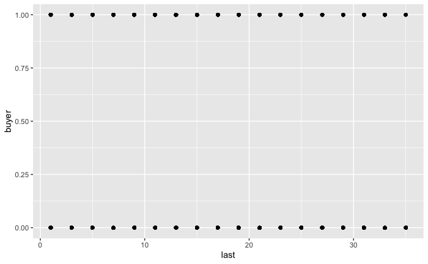

```r
ggplot(data = bbb) +
  geom_point(mapping = aes(x = last,y = buyer))
```

Instead, we bin our the observations for plotting (here we use 20 bins as indicated in the code):

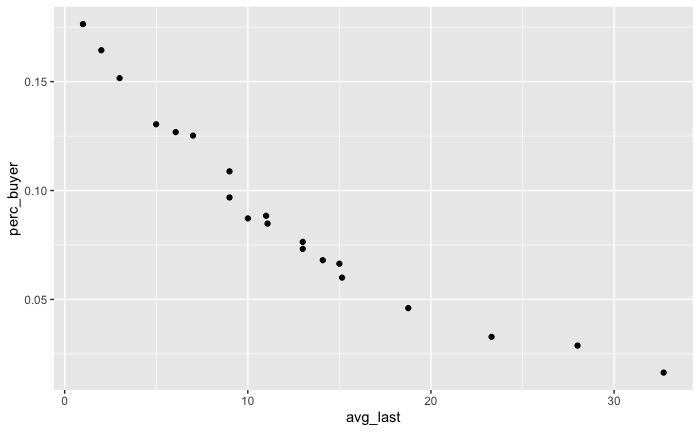

```r
bbb %>%
    group_by(ntile(last, 20)) %>%
    summarize(avg_last = mean(last), perc_buyer = mean(buyer)) %>%
    ggplot(mapping = aes(x = avg_last,y = perc_buyer)) + geom_point()
```

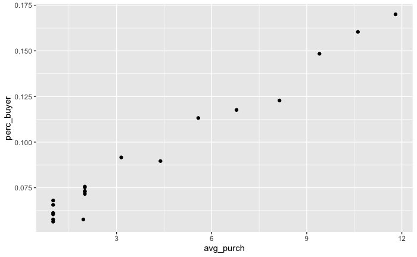

```r
bbb %>%
    group_by(ntile(purch, 20)) %>%
    summarize(avg_purch = mean(purch), perc_buyer = mean(buyer)) %>%
    ggplot(mapping = aes(x = avg_purch,y = perc_buyer)) + geom_point()
```

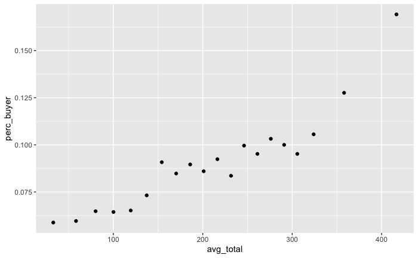

```r
bbb %>%
    group_by(ntile(total, 20)) %>%
    summarize(avg_total = mean(total), perc_buyer = mean(buyer)) %>%
    ggplot(mapping = aes(x = avg_total,y = perc_buyer)) + geom_point()
```

As can be seen, the answer to our question is yes for recency (`last`) but not frequency and monetary value (`purch` and `total` respectively), hence we need to apply a minus sign `-` when creating the F and M quintiles below.

## Independent Quintiles

To distinquish between independent, sequential, and intuitive approaches we carry the ending `_i` for the independent quintile approach in this subsection. We create new variables `rec_quin_i`, `freq_quin_i`, and `mon_quin_i` which contain the quintiles for recency, frequency, and monetary value. We use the basic `dplyr` functionality `mutate` to create new variables and utilize the `ntile` function to create quintiles (see the `5` in the call to the `ntile` function.)

```r
bbb_iq <- bbb %>%
  mutate(rec_quin_i = ntile(last, 5),
         freq_quin_i = ntile(-purch, 5),
         mon_quin_i = ntile(-total, 5))

bbb_iq %>%
  select(buyer, last, purch, total, rec_quin_i, freq_quin_i, mon_quin_i)
```

| buyer | last | purch | total | rec_quin_i | freq_quin_i | mon_quin_i |
| --- | --- | --- | --- | --- | --- | --- |
| 0 | 29 | 10 | 357 | 5 | 1 | 1 |
| 0 | 27 | 3 | 138 | 5 | 2 | 4 |
| 0 | 15 | 2 | 172 | 4 | 2 | 4 |
| 0 | 7 | 1 | 272 | 2 | 4 | 2 |
| 0 | 15 | 1 | 149 | 4 | 4 | 4 |
| 1 | 7 | 1 | 113 | 2 | 4 | 4 |
| 0 | 25 | 1 | 15 | 5 | 4 | 5 |
| 0 | 1 | 11 | 238 | 1 | 1 | 3 |
| 1 | 5 | 11 | 418 | 1 | 1 | 1 |
| 0 | 11 | 1 | 123 | 3 | 4 | 4 |

[output cut: 990 more lines]

Given this, a customer with a 111 should belong to the first quintile for recency, for frequency, and for monetary and a customer with a 243 should belong to the second quintile for recency, the fourth quintile for frequency and the third quintile for monetary.

Let’s double check: We should find that the highest purchase probability is found for customers in the first quintile for all three variables.

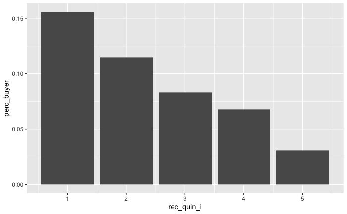

```r
bbb_iq %>%
  group_by(rec_quin_i) %>%
  summarize(perc_buyer = mean(buyer)) %>%
  ggplot() + geom_col(aes(x = rec_quin_i, y = perc_buyer))
```

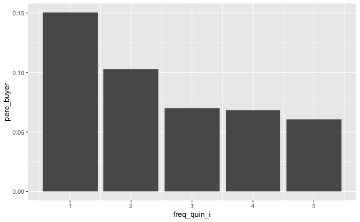

```r
bbb_iq %>%
  group_by(freq_quin_i) %>%
  summarize(perc_buyer = mean(buyer)) %>%
  ggplot() + geom_col(aes(x = freq_quin_i, y = perc_buyer))
```

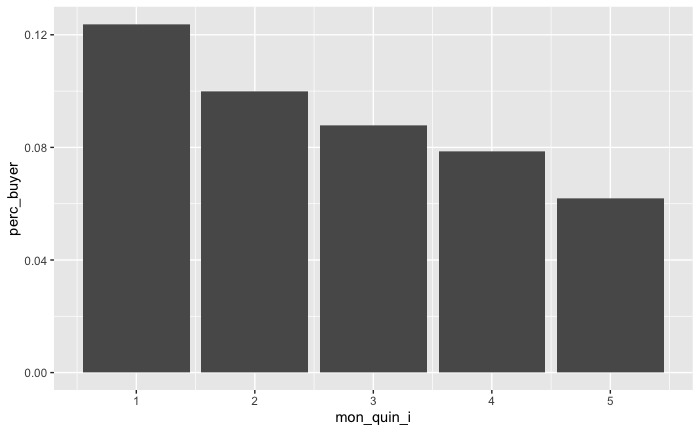

```r
bbb_iq %>%
  group_by(mon_quin_i) %>%
  summarize(perc_buyer = mean(buyer)) %>%
  ggplot() + geom_col(aes(x = mon_quin_i, y = perc_buyer))
```

This looks good!

```r
bbb_iq %>%
  group_by(rec_quin_i) %>%
  summarise(perc_buyer=mean(buyer)) %>%
  ggplot() + geom_col(aes(x = rec_quin_i, y = perc_buyer))
```

This would produce an identical plot.

One interesting question is whether R, F, and M are correlated. We know from the above plots that they predict “buyer” but do they contain the same information? Let’s see:

```r
bbb %>%
  select(last,purch,total) %>%
  cor() %>%
  round(4)
```

```
         last  purch   total
last   1.0000 0.0060 -0.0019
purch  0.0060 1.0000  0.5153
total -0.0019 0.5153  1.0000
```

For this data, the answer is R and F and R and M are uncorrelated while F and M are moderately correlated.

Now, let’s construct the independent quintile index and plot response rates. The `paste` command concatenates the three quantiles into a single index.

```r
bbb_iq <- bbb_iq %>%
  mutate(rfmindex_iq = paste(rec_quin_i, freq_quin_i, mon_quin_i, sep = ''))

bbb_iq %>%
  select(rec_quin_i, freq_quin_i, mon_quin_i, rfmindex_iq) %>%
  head()
```

| rec_quin_i | freq_quin_i | mon_quin_i | rfmindex_iq |
| --- | --- | --- | --- |
| 5 | 1 | 1 | 511 |
| 5 | 2 | 4 | 524 |
| 4 | 2 | 4 | 424 |
| 2 | 4 | 2 | 242 |
| 4 | 4 | 4 | 444 |
| 2 | 4 | 4 | 244 |

We can now plot the response rate by independent RFM index:

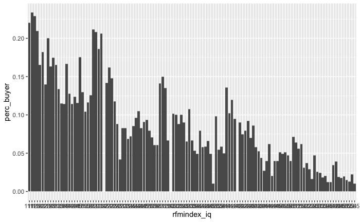

```r
bbb_iq %>%
  group_by(rfmindex_iq) %>%
  summarise(perc_buyer=mean(buyer)) %>%
  ggplot() + geom_col(aes(x = rfmindex_iq, y = perc_buyer))
```

## Sequential Quintiles

To distinquish between independent, sequential, and intuitive approaches we carry the ending `_s` for the sequential quintile approach in this subsection. Let’s construct the sequential quintile index:

```r
bbb_iq_sq <- bbb_iq %>%
  mutate(rec_quin_s = ntile(last, 5)) %>%
  group_by(rec_quin_s) %>%
  mutate(freq_quin_s = ntile(-purch, 5)) %>%
  group_by(rec_quin_s, freq_quin_s) %>%
  mutate(mon_quin_s = ntile(-total, 5)) %>%
  ungroup()
```

```r
bbb_iq_sq <- bbb_iq_sq %>%
  mutate(rfmindex_sq = paste(rec_quin_s, freq_quin_s, mon_quin_s, sep = ''))

bbb_iq_sq %>%
  select(rec_quin_s, freq_quin_s, mon_quin_s,rfmindex_sq) %>%
  head()
```

| rec_quin_s | freq_quin_s | mon_quin_s | rfmindex_sq |
| --- | --- | --- | --- |
| 5 | 1 | 2 | 512 |
| 5 | 2 | 5 | 525 |
| 4 | 3 | 3 | 433 |
| 2 | 4 | 1 | 241 |
| 4 | 4 | 3 | 443 |
| 2 | 4 | 4 | 244 |

We can now plot the response rate by sequential RFM index:

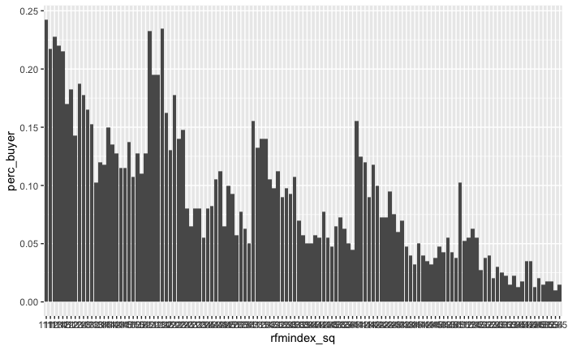

```r
bbb_iq_sq %>%
  group_by(rfmindex_sq) %>%
  summarise(perc_buyer=mean(buyer)) %>%
  ggplot() + geom_col(aes(x = rfmindex_sq, y = perc_buyer))
```

## Calculating the Average Response Rate and Mail To Indicators for Each RFM Index

First, we calculate the average response rate for the independent RFM index:

```r
resp_rate_iq_df <- bbb_iq_sq %>%
  group_by(rfmindex_iq) %>%
  summarise(resp_rate_iq=mean(buyer)) %>%
  ungroup()

resp_rate_iq_df %>%
  head()
```

| rfmindex_iq | resp_rate_iq |
| --- | --- |
| 111 | 0.2205177 |
| 112 | 0.2338308 |
| 113 | 0.2288557 |
| 114 | 0.2094241 |
| 121 | 0.1652720 |
| 122 | 0.1820449 |

Next, we calculate the average response rate for the sequential RFM index:

```r
resp_rate_sq_df <- bbb_iq_sq %>%
  group_by(rfmindex_sq) %>%
  summarise(resp_rate_sq=mean(buyer)) %>%
  ungroup()

resp_rate_sq_df %>%
  head()
```

| rfmindex_sq | resp_rate_sq |
| --- | --- |
| 111 | 0.2425 |
| 112 | 0.2175 |
| 113 | 0.2275 |
| 114 | 0.2200 |
| 115 | 0.2150 |
| 121 | 0.1700 |

Now, we merge both response rate predictions back into the main data:

```r
bbb_final <- bbb_iq_sq %>%
  left_join(resp_rate_iq_df) %>%
  left_join(resp_rate_sq_df)
bbb_final %>%
  select(acctnum,buyer,rfmindex_iq,resp_rate_iq,rfmindex_sq,resp_rate_sq) %>%
  head()
```

| acctnum | buyer | rfmindex_iq | resp_rate_iq | rfmindex_sq | resp_rate_sq |
| --- | --- | --- | --- | --- | --- |
| 10001 | 0 | 511 | 0.07121058 | 512 | 0.0525 |
| 10002 | 0 | 524 | 0.01594533 | 525 | 0.0300 |
| 10003 | 0 | 424 | 0.09227468 | 433 | 0.0475 |
| 10004 | 0 | 242 | 0.09615385 | 241 | 0.0825 |
| 10005 | 0 | 444 | 0.03962704 | 443 | 0.0350 |
| 10006 | 1 | 244 | 0.08275862 | 244 | 0.0650 |

Finally, we want to create a variable that tells us whether we should or should not mail to a given customer. To do so, we need the break-even response rate which can be determined from the information about revenues and costs contained in the case; the break-even response rate is `0.50 / (18 - 9 - 3) = 0.083` (or 8.3%). With this information, we can create a binary (0/1 or indicator or dummy) variable that indicates whether the predicted response rate for the customer is greater than the breakeven rate.

```r
bbb_final <- bbb_final %>%
  mutate(mailto_iq=1*(resp_rate_iq>0.083), mailto_sq=1*(resp_rate_sq>0.083))

bbb_final %>%
  select(rfmindex_iq, resp_rate_iq, mailto_iq, rfmindex_sq,resp_rate_sq,mailto_sq) %>%
  head()
```

| rfmindex_iq | resp_rate_iq | mailto_iq | rfmindex_sq | resp_rate_sq | mailto_sq |
| --- | --- | --- | --- | --- | --- |
| 511 | 0.07121058 | 0 | 512 | 0.0525 | 0 |
| 524 | 0.01594533 | 0 | 525 | 0.0300 | 0 |
| 424 | 0.09227468 | 1 | 433 | 0.0475 | 0 |
| 242 | 0.09615385 | 1 | 241 | 0.0825 | 0 |
| 444 | 0.03962704 | 0 | 443 | 0.0350 | 0 |
| 244 | 0.08275862 | 0 | 244 | 0.0650 | 0 |

## Calculating Profitability

Now we calculate profit calculations for the benchmark (no targeting) and for both RFM approaches.

For the no targeting benchmark, we first need to calculate the response rate:

```r
bbb_final %>%
  summarise(mean(buyer))
```

| mean(buyer) |
| --- |
| 0.09044 |

Now, we can calculate profit by hand.

For the independent RFM approach, we first need to calculate the mailto rate and the response rate among those mailed to:

```r
bbb_final %>%
  filter(mailto_iq==1) %>%
  summarise(frac_mailed=n()/nrow(bbb_final), resp_rate=mean(buyer))
```

| frac_mailed | resp_rate |
| --- | --- |
| 0.46582 | 0.1400112 |

Now, we can calculate profit by hand.

For the sequential RFM approach, we first need to calculate the mailto rate and the response rate among those mailed to:

```r
bbb_final %>%
  filter(mailto_sq==1) %>%
  summarise(frac_mailed=n()/nrow(bbb_final), resp_rate=mean(buyer))
```

| frac_mailed | resp_rate |
| --- | --- |
| 0.456 | 0.1419737 |

Now, we can calculate profit by hand.